# Soluções da Lista de Exercícios - Treinamento para a Avaliação 2

## Tópico: Correlação e Diversificação de Carteiras

### Exercício 5

1. Use `tq_get()` para baixar as séries de preços das ações da Vale (VALE3) e do Bradesco (BBDC4) desde `2024-01-01`

```r
library(tidyquant)

# Baixar os preços das ações desde 2024-01-01
dados_acoes <- tq_get(c("VALE3.SA", "BBDC4.SA"),
                      from = "2024-01-01",
                      get = "stock.prices")

# Visualizar os primeiros registros
head(dados_acoes)
```

```
# A tibble: 6 × 8
  symbol   date        open  high   low close   volume adjusted
  <chr>    <date>     <dbl> <dbl> <dbl> <dbl>    <dbl>    <dbl>
1 VALE3.SA 2024-01-02  77.6  78.2  76.6  77.1 18021800     67.9
2 VALE3.SA 2024-01-03  76.7  76.9  75.8  76.7 25315100     67.5
3 VALE3.SA 2024-01-04  76.4  76.6  75.4  75.6 18707000     66.6
4 VALE3.SA 2024-01-05  75.0  75.1  74.1  74.7 21082500     65.8
5 VALE3.SA 2024-01-08  73.9  74.6  73.5  74.3 23013300     65.4
6 VALE3.SA 2024-01-09  74.1  74.2  73.2  73.3 15257400     64.6
```

2. Organize os dados com `pivot_wider()`.

```r
library(tidyr)
library(dplyr)

# Seleciona apenas as colunas relevantes
dados_wide <- dados_acoes %>%
  select(date, symbol, close) %>%
  pivot_wider(
    names_from = symbol,
    values_from = close
  )

# Visualiza as primeiras linhas
head(dados_wide)
```

```
# A tibble: 6 × 3
  date       VALE3.SA BBDC4.SA
  <date>        <dbl>    <dbl>
1 2024-01-02     77.1     16.8
2 2024-01-03     76.7     16.8
3 2024-01-04     75.6     16.5
4 2024-01-05     74.7     16.9
5 2024-01-08     74.3     16.8
6 2024-01-09     73.3     16.3
```

3. Calcule a **correlação de Pearson** entre os preços e interprete sua magnitude usando os critérios propostos por Cohen (1988).

Estimativa do coeficiente de correlação de Pearson:

```r
# Calculando a correlação de Pearson entre VALE3.SA e BBDC4.SA
correlacao <- cor(dados_wide$VALE3.SA, dados_wide$BBDC4.SA, use = "complete.obs")
correlacao
```

```
[1] 0.36775
```

Interpretação da magnitude usando a função interpret_r do pacote effectsize:

```r
library(effectsize)

# Calcula a correlação de Pearson
correlacao <- cor(dados_wide$VALE3.SA, dados_wide$BBDC4.SA, use = "complete.obs")

# Interpreta a magnitude segundo Cohen (1988)
interpretacao <- interpret_r(correlacao)
interpretacao
```

```
[1] "large"
(Rules: funder2019)
```

4. Crie um gráfico de dispersão com reta de regressão para as séries de preços e interprete do gráfico considerando o coeficiente de correlação de Pearson estimado

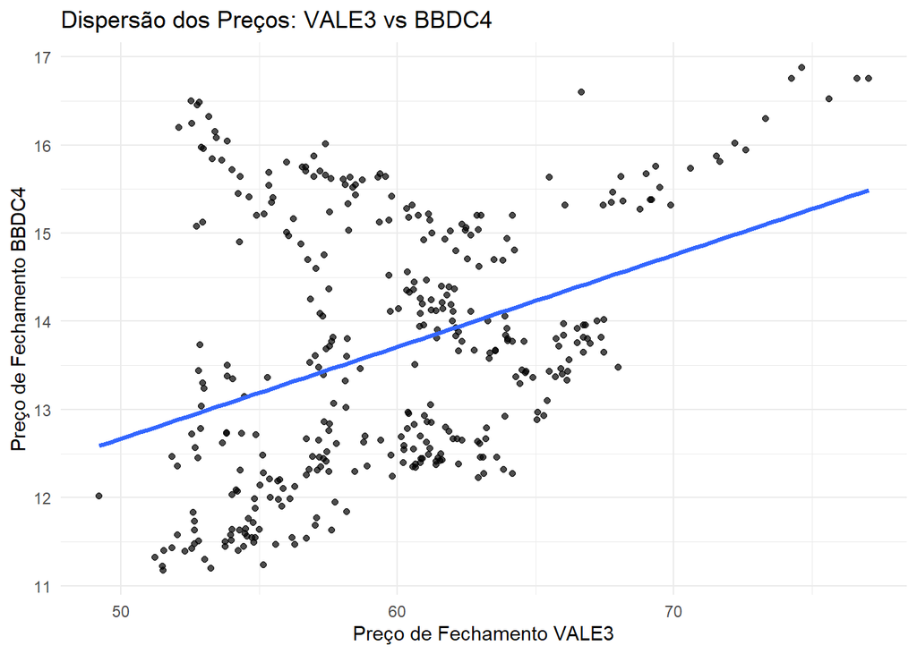

```r
library(ggplot2)

ggplot(dados_wide, aes(x = VALE3.SA, y = BBDC4.SA)) +
  geom_point(alpha = 0.7) +
  geom_smooth(method = "lm", se = FALSE, linewidth = 1.2) +
  labs(
    title = "Dispersão dos Preços: VALE3 vs BBDC4",
    x = "Preço de Fechamento VALE3",
    y = "Preço de Fechamento BBDC4"
  ) +
  theme_minimal()
```

5. Avalie se uma carteira formada por essas duas ações poderia ser considerada bem diversificada, com base na correlação estimada e na análise do gráfico de dispersão.